# Analisis de resultados Rubus glaucus

Herney Dario Vasquez, Diego Rojas, Deysi Johana Guerrero, Viviana Eugenia Castro y Luis Fernando Delgado Muñoz

01/03/2022

# Resultados

A continuación se presentan los resultados de producción, calidad y estado fitosanitario del 3 materiales de Mora evaluados durante los periodos 2020 y 2021 bajo macrotúneles.

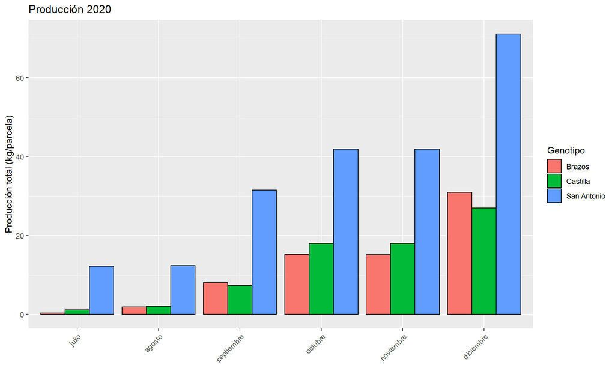

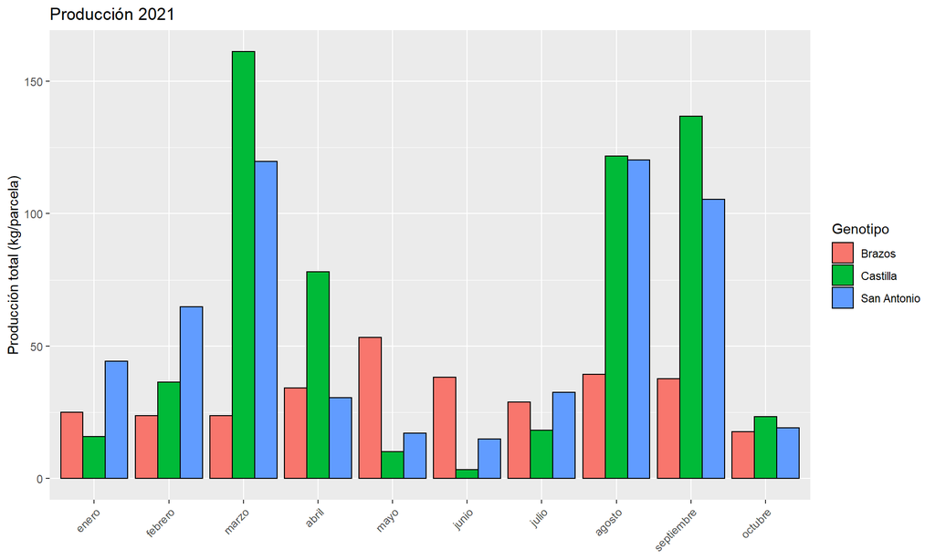

En las graficas previas e puede visualizar las producciones totales que hubo por material en cada periodo de evaluación (años 2020 y 2021). Para el primer periodo de evaluación se pudo notar que el genotipo **San Antonio** fue el que mas producción tuvo, alcanzando un una producción total de 71 kg para el mes de diciembre, mientras que Castilla y Brazos tuvieron una producción total de 27 y 30 kg respectivamente para el mes de diciembre. La producción acumulada correspondiente al periodo de 2020 puede verse en la siguiente tabla:

| Nombre del genotipo | Producción (kg/parcela) |
| --- | --- |
| San Antonio | 211.037 |
| Castilla | 73.510 |
| Brazos | 71.505 |

Para el periodo 2021 se pudo evidenciar una estacionalidad en la producción, es decir, en los meses de marzo y agosto - septiembre se produjeron 2 picos de producción para los materiales Castilla y San Antonio, mientras que el material Brazos no mostró picos, puesto que su producción fue muy estable durante el periodo 2021. Las producciones acumuladas para el periodo 2021 pueden verse en la siguiente tabla.

| Nombre del genotipo | Producción (kg/parcela) |
| --- | --- |
| Castilla | 604.9 |
| San Antonio | 568.5 |
| Brazos | 321.9 |

Es importante aclarar que las producciones acumuladas en cada periodo de evaluación mostradas previamente corresponden a poblaciones de plantas productivas en cada parcela; dichas poblaciones pueden verse en la siguiente tabla

| Nombre del genotipo | Número de plantas productivas | Dimensiones de siembra (largo x ancho) |
| --- | --- | --- |
| San Antonio | 126 | 1.6m X 2m |
| Castilla | 85 | 1.82m X 3m |
| Brazos | 53 | 1.46m X 2m |

# Análisis de varianza año 2020

La siguiente tabla muestra el análisis de varianza para el periodo de evaluación 2020, donde se puede evidenciar que el efecto “Genotipo” fue altamente significativo, es decir, que por lo menos uno de los materiales evaluados es estadísticamente diferente a los demás.

|  | Df | Sum Sq | Mean Sq | F value | Pr(>F) |
| --- | --- | --- | --- | --- | --- |
| Genotipo | 2 | 36.82567 | 18.412834 | 12.70077 | 2.321356e-05 |
| Residuals | 63 | 91.33370 | 1.449741 | NA | NA |

Se llevó a cabo una prueba post Anova basada en el agrupamiento del criterio de Tukey.

Efectivamente como se mencionó previamente, se observo que entre los 3 materiales evaluados, el que mejor producción en promedio tuvo para el periodo 2020 fue el genotipo San Antonio con un promedio de 2.064 kg/planta, seguido de Castilla sin espinas con 0.507 kg/planta y finalmente Brazos con 0.453 kg/planta. Las producciones proendio de Brazos y Castilla resultaron ser estadisticamente iguales (misma letra de agrupamiento), mientras que el promedio de producción de San Antonio fue estadisticamente diferente de los otros dos promedios.

|  | Genotipo | emmean | SE | df | lower.CL | upper.CL | .group |
| --- | --- | --- | --- | --- | --- | --- | --- |
| 1 | Brazos | 0.4530114 | 0.2567048 | 63 | -0.059972146 | 0.9659949 | a |
| 2 | Castilla | 0.5071591 | 0.2567048 | 63 | -0.005824419 | 1.0201426 | a |
| 3 | San Antonio | 2.0639545 | 0.2567048 | 63 | 1.550971036 | 2.5769381 | b |

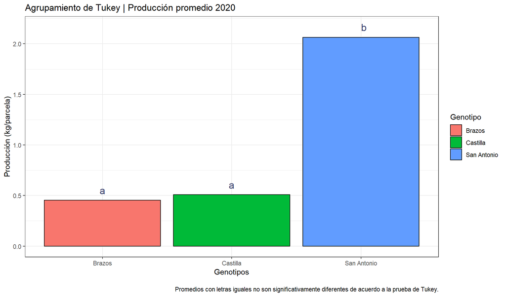

En la gráfica anterior se ve representado el agrupamiento de Tukey para cada material evaluado.

# Analisis de varianza año 2021

La siguiente tabla muestra el análisis de varianza para el periodo de evaluación 2021, donde se puede evidenciar que el efecto “Genotipo” fue altamente significativo, es decir, que se estaría aceptando la hipotesis alternativa que indica que por lo menos uno de los materiales evaluados es estadísticamente diferente a los demás.

|  | Df | Sum Sq | Mean Sq | F value | Pr(>F) |
| --- | --- | --- | --- | --- | --- |
| Genotipo | 2 | 571.1868 | 285.59341 | 7.677195 | 0.0005831132 |
| Residuals | 246 | 9151.2564 | 37.20023 | NA | NA |

Se llevó a cabo una prueba post Anova basada en el agrupamiento del criterio de Tukey.

La siguinete tabla muestra que entre los 3 materiales evaluados, el que mejor producción en promedio tuvo para el periodo 2021 fue el genotipo Castilla con un promedio de 7.29 kg/planta, seguido de San Antonio con 6.85 kg/planta y finalmente Brazos con 3.88 kg/planta. Las producciones promedio de San Antonio y Castilla resultaron ser estadisticamente iguales (misma letra de agrupamiento), mientras que el promedio de producción de Brazos fue estadisticamente diferente de los otros dos promedios.

|  | Genotipo | emmean | SE | df | lower.CL | upper.CL | .group |
| --- | --- | --- | --- | --- | --- | --- | --- |
| 1 | Brazos | 3.878313 | 0.6694741 | 246 | 2.559681 | 5.196946 | a |
| 3 | San Antonio | 6.849398 | 0.6694741 | 246 | 5.530765 | 8.168030 | b |
| 2 | Castilla | 7.287952 | 0.6694741 | 246 | 5.969319 | 8.606584 | b |

A continuación se muestra la representación gráfica del agrupamiento de Tukey mediante un diagrama de barras.

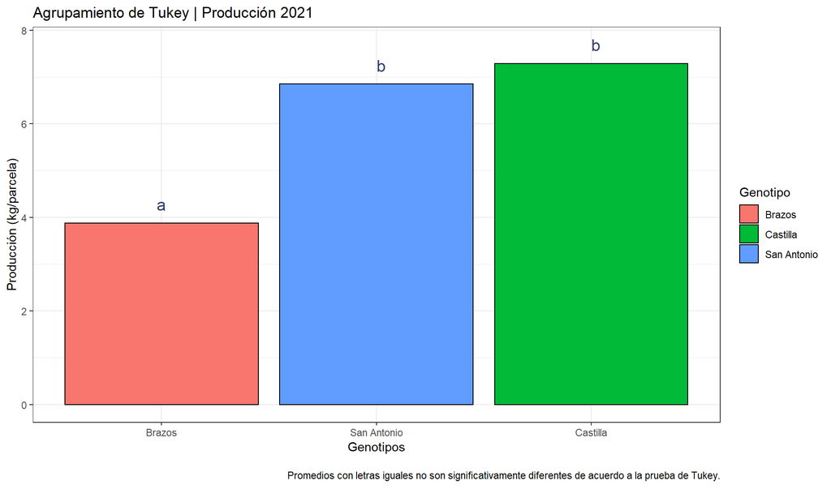

# Analisis de varianza de la interacción 2021

Adicionalmente al analisis de varianza presentado previamente, se decidió llevar a cabo un nuevo analisis de la varianza con un modelo factorial con interacción en función del genotipo, producción mensual y la interacción genotipo*producción mensual solo para el año mas productivo que fue el 2021. Este analisis se hizo con el objetivo de destacar cuales cosechas dentro de cada genotipo presentaron diferencias estadisticas significativas.

|  | Df | Sum Sq | Mean Sq | F value | Pr(>F) |
| --- | --- | --- | --- | --- | --- |
| Genotipo | 2 | 571.1868 | 285.59341 | 15.469398 | 5.198085e-07 |
| Month | 9 | 2946.8919 | 327.43244 | 17.735643 | 5.950409e-22 |
| Genotipo:Month | 18 | 2161.2234 | 120.06797 | 6.503578 | 7.625292e-13 |
| Residuals | 219 | 4043.1410 | 18.46183 | NA | NA |

El analisis de varianza mostró que tanto los Genotipos como los meses de cosecha y la interacción entre los genotipos y las cosechas fueron altamente significativos.

A continuación se muestra la producción promedio de cada mes para el genotipo Castilla; donde se destacó los picos mas altos de producción que correspondieron a los meses agosto con 13.522 kg, septiembre con 15.200 kg y finalmente marzo con la producción promedia mas alta con 17.911 kg.

| Genotipo | Month | emmean | SE | df | lower.CL | upper.CL | .group |
| --- | --- | --- | --- | --- | --- | --- | --- |
| Castilla | junio | 0.412500 | 1.519121 | 219 | -2.58146796 | 3.406468 | a |
| Castilla | mayo | 1.122222 | 1.432241 | 219 | -1.70051784 | 3.944962 | ab |
| Castilla | julio | 2.022222 | 1.432241 | 219 | -0.80051784 | 4.844962 | ab |
| Castilla | enero | 2.650000 | 1.754130 | 219 | -0.80713642 | 6.107136 | ab |
| Castilla | octubre | 2.912500 | 1.519121 | 219 | -0.08146796 | 5.906468 | ab |
| Castilla | febrero | 5.200000 | 1.624009 | 219 | 1.99931362 | 8.400686 | abcd |
| Castilla | abril | 8.666667 | 1.432241 | 219 | 5.84392660 | 11.489407 | bcdef |
| Castilla | agosto | 13.522222 | 1.432241 | 219 | 10.69948216 | 16.344962 | efg |
| Castilla | septiembre | 15.200000 | 1.432241 | 219 | 12.37725994 | 18.022740 | fg |
| Castilla | marzo | 17.911111 | 1.432241 | 219 | 15.08837105 | 20.733851 | g |

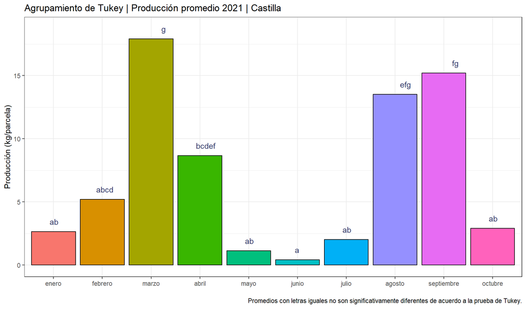

| Genotipo | Month | emmean | SE | df | lower.CL | upper.CL | .group |
| --- | --- | --- | --- | --- | --- | --- | --- |
| San Antonio | junio | 1.875000 | 1.519121 | 219 | -1.1189680 | 4.868968 | ab |
| San Antonio | mayo | 1.900000 | 1.432241 | 219 | -0.9227401 | 4.722740 | ab |
| San Antonio | octubre | 2.387500 | 1.519121 | 219 | -0.6064680 | 5.381468 | ab |
| San Antonio | abril | 3.388889 | 1.432241 | 219 | 0.5661488 | 6.211629 | ab |
| San Antonio | julio | 3.611111 | 1.432241 | 219 | 0.7883710 | 6.433851 | ab |
| San Antonio | enero | 7.383333 | 1.754130 | 219 | 3.9261969 | 10.840470 | abcdef |
| San Antonio | febrero | 9.257143 | 1.624009 | 219 | 6.0564565 | 12.457829 | bcdef |
| San Antonio | septiembre | 11.700000 | 1.432241 | 219 | 8.8772599 | 14.522740 | cdefg |
| San Antonio | marzo | 13.288889 | 1.432241 | 219 | 10.4661488 | 16.111629 | defg |
| San Antonio | agosto | 13.366667 | 1.432241 | 219 | 10.5439266 | 16.189407 | defg |

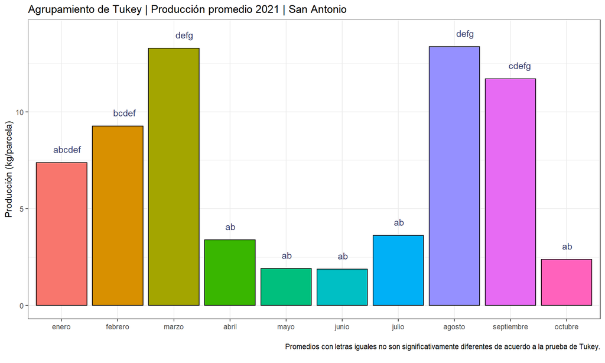

Finalmente a continuación se muestra la producción promedio del genotipo Brazos para cada mes; donde se evidenció que todas producciones mensuales no fueron estadisiticamente diferentes; confirmando la hipotesis nula que indica que todas los promedios deben der iguales en terminos estadisticos. Es por esta razón todos los promedios de producción se clasificaron en un solo grupo de acuerdo al criterio de Tukey.

| Genotipo | Month | emmean | SE | df | lower.CL | upper.CL | .group |
| --- | --- | --- | --- | --- | --- | --- | --- |
| Brazos | octubre | 2.200000 | 1.519121 | 219 | -0.7939680 | 5.193968 | ab |
| Brazos | marzo | 2.633333 | 1.432241 | 219 | -0.1894067 | 5.456073 | ab |
| Brazos | julio | 3.200000 | 1.432241 | 219 | 0.3772599 | 6.022740 | ab |
| Brazos | febrero | 3.400000 | 1.624009 | 219 | 0.1993136 | 6.600686 | ab |
| Brazos | abril | 3.800000 | 1.432241 | 219 | 0.9772599 | 6.622740 | ab |
| Brazos | enero | 4.183333 | 1.754130 | 219 | 0.7261969 | 7.640470 | abc |
| Brazos | septiembre | 4.188889 | 1.432241 | 219 | 1.3661488 | 7.011629 | abc |
| Brazos | agosto | 4.377778 | 1.432241 | 219 | 1.5550377 | 7.200518 | abc |
| Brazos | junio | 4.787500 | 1.519121 | 219 | 1.7935320 | 7.781468 | abc |
| Brazos | mayo | 5.922222 | 1.432241 | 219 | 3.0994822 | 8.744962 | abcde |

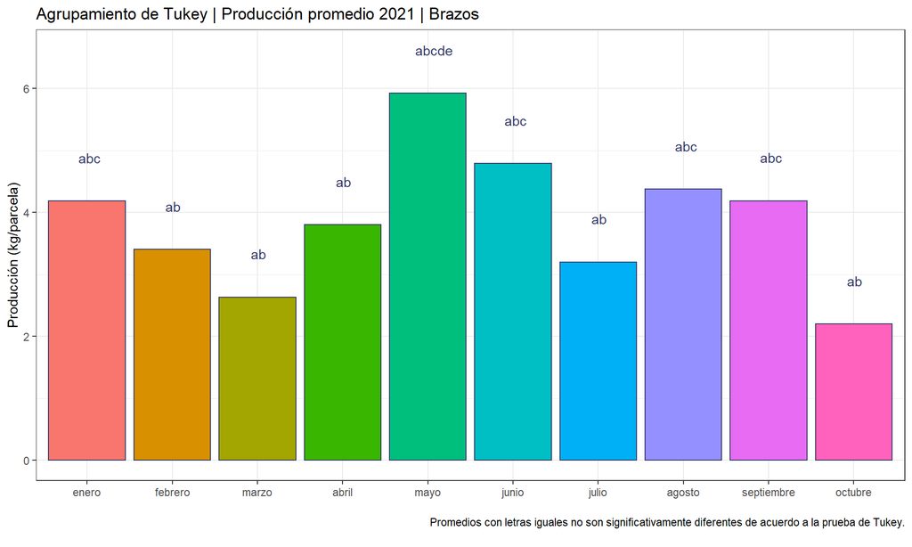

# Producción estandarizada

A continuación se llevo a cabo el ajuste de los datos de producción mediante un calculo de estandarización de acuerdo a la muestra del material Brazos. Dicha estandarización se hizo teniendo en cuenta la siguiente ecuación:

$$\text{Pn estandarizada = } (\text{Producción mensual}{\div} \text{número de plantas productivas})\star\ \text{numero de plantas productivas del genotipo Brazos}$$
La estandarización se hizo con respecto al genotipo Brazos ya que este fue el menos muestra de plantas productivas tuvo y por ende fue necesario que el resto de los materiales tambien se analizaran bajo el mismo número de muestra.

# Producción acumulada estandarizada año 2020

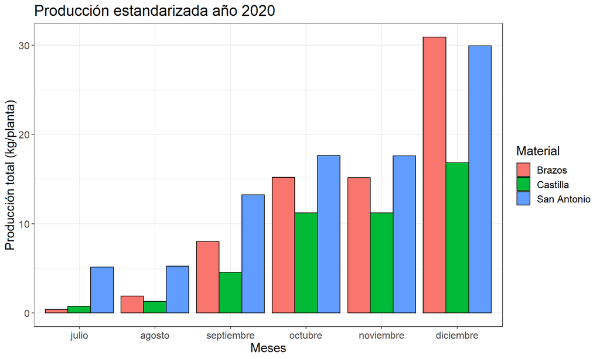

# Producción acumulada estandarizada año 2021

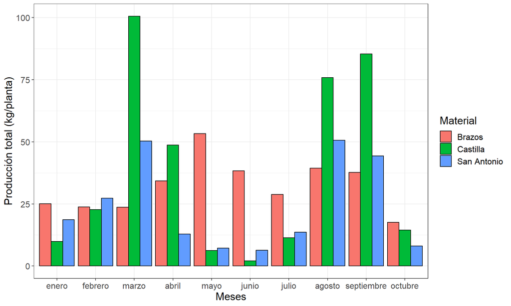

En las graficas previas se pudo visualizar las producciones estandarizadas totales por material para cada periodo de evaluación (años 2020 y 2021). Para el primer periodo de evaluación se pudo notar que el tanto el genotipo San Antonio como el genotipo Brazos fueron los que mas producción tuvieron para el mes de diciembre 2020, alcanzando un una cifra total decembrina total de 29.90 y 30.90 kgrespectivamente, mientras que Castilla tuvo una producción de 16.83 kg para el mes de diciembre. La producción acumulada correspondiente al periodo de 2020 puede verse en la siguiente tabla:

| Nombre del genotipo | Producción (kg/parcela) |
| --- | --- |
| San Antonio | 88.769 |
| Brazos | 71.505 |
| Castilla | 45.835 |

| Nombre del genotipo | Producción (kg/parcela) |
| --- | --- |
| Castilla | 377.1 |
| Brazos | 321.9 |
| San Antonio | 239.1 |

A continuación se muestra el analisis de varianza para la variable producción estandarizada para el año 2020. Se llevo a cabo bajo un modelo completamente al azar en donde los materiales evaluados correspondieron a la variable independiente y la producción estandarizada correspondió a la variable dependiente.

# Analisis de varianza año 2020 estandarizada

|  | Df | Sum Sq | Mean Sq | F value | Pr(>F) |
| --- | --- | --- | --- | --- | --- |
| Genotipo_estandarizado | 2 | 10.90558 | 5.4527895 | 11.79015 | 1.466562e-05 |
| Residuals | 195 | 90.18494 | 0.4624869 | NA | NA |

El analisis de varianza mostró que los materiales fueron estadisticamente significativos, por lo cual, se acepta la hipótesis alternativa que indica que por lo menos un material evaluado es diferente a los demas. A continuación se lleva a cabo la prueba post anova de Tukey.

|  | Genotipo_estandarizado | emmean | SE | df | lower.CL | upper.CL | .group |
| --- | --- | --- | --- | --- | --- | --- | --- |
| 2 | Castilla Estandarizada | 0.3162286 | 0.08371008 | 195 | 0.1511353 | 0.4813220 | a |
| 1 | Brazos Estandarizada | 0.4530114 | 0.08371008 | 195 | 0.2879180 | 0.6181047 | a |
| 3 | San Antonio Estandarizada | 0.8681714 | 0.08371008 | 195 | 0.7030780 | 1.0332647 | b |

La prueba de medias mostró que la producción promedio mas grande fue la del material San Antonio con 0.86 kg/planta, seguido de Brazos con 0.453 kg/planta y finalmente la producción promedio de Castilla con 0.316 kg/planta.

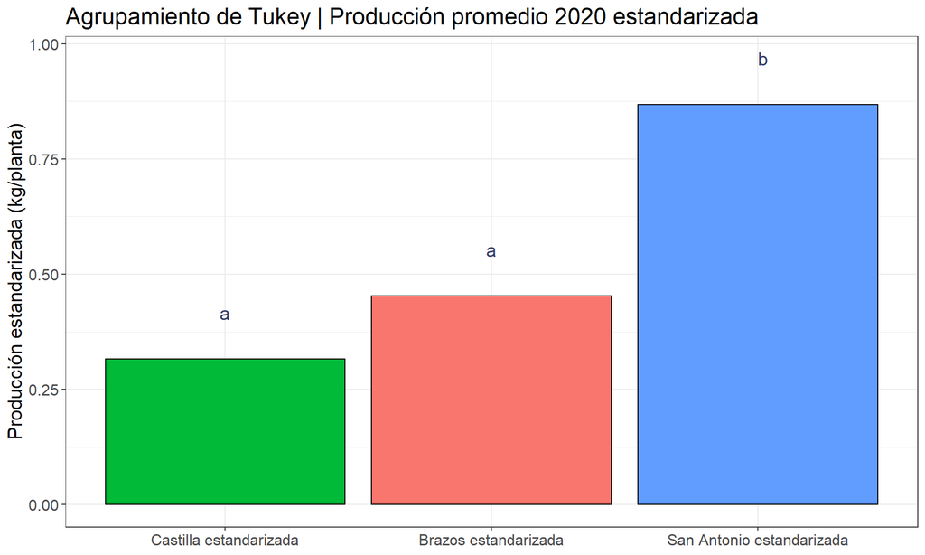

# Analisis de varianza año 2021

|  | Df | Sum Sq | Mean Sq | F value | Pr(>F) |
| --- | --- | --- | --- | --- | --- |
| Genotipo_estandarizado | 2 | 348.9326 | 174.46629 | 14.1394 | 9.40072e-07 |
| Residuals | 744 | 9180.2269 | 12.33901 | NA | NA |

El analisis de varianza para el año 2021 mostró que los materiales fueron estadisticamente significativos, por lo cual, se acepta la hipótesis alternativa que indica que por lo menos un material evaluado es diferente a los demas. A continuación se lleva a cabo la prueba post anova de Tukey.

|  | Genotipo_estandarizado | emmean | SE | df | lower.CL | upper.CL | .group |
| --- | --- | --- | --- | --- | --- | --- | --- |
| 3 | San Antonio Estandarizada | 2.881096 | 0.2226079 | 744 | 2.444081 | 3.318110 | a |
| 1 | Brazos Estandarizada | 3.878313 | 0.2226079 | 744 | 3.441299 | 4.315328 | b |
| 2 | Castilla Estandarizada | 4.544252 | 0.2226079 | 744 | 4.107238 | 4.981267 | b |

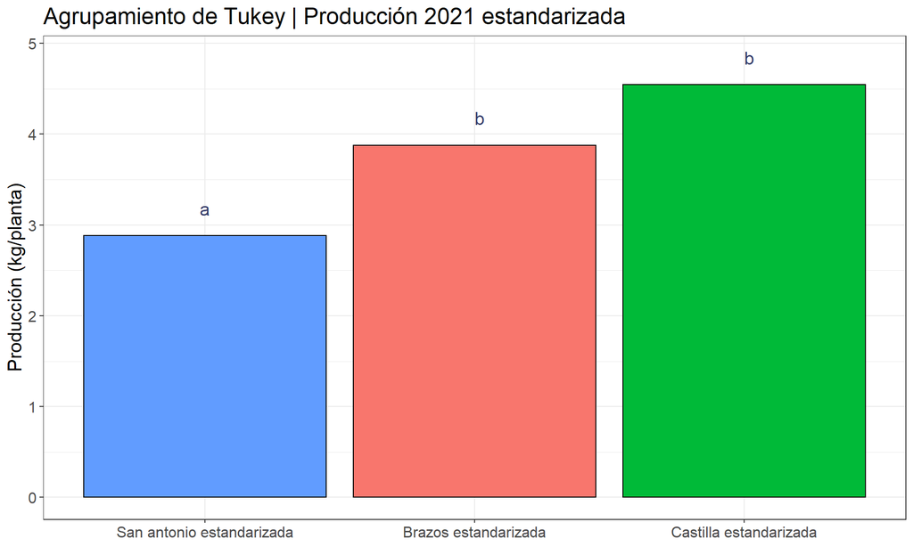

# Analisis de varianza de la interacción 2021

Adicionalmente al analisis de varianza presentado previamente, se decidió llevar a cabo un nuevo analisis de la varianza con los datos estadnarizados con un modelo factorial con interacción en función del genotipo, producción mensual y la interacción genotipo*producción mensual. Este analisis solo se llevó a cabo para el año mas productivo que fue el 2021. Este analisis se hizo con el objetivo de destacar cuales cosechas dentro de cada genotipo presentaron diferencias estadisticas significativas.

|  | Df | Sum Sq | Mean Sq | F value | Pr(>F) |
| --- | --- | --- | --- | --- | --- |
| Genotipo_estandarizado | 2 | 348.9326 | 174.466289 | 29.82489 | 3.613063e-13 |
| Month | 9 | 2511.1953 | 279.021701 | 47.69856 | 2.216601e-67 |
| Genotipo_estandarizado:Month | 18 | 2474.8053 | 137.489182 | 23.50368 | 1.738955e-60 |
| Residuals | 717 | 4194.2263 | 5.849688 | NA | NA |

El analisis de varianza mostró que tanto los Genotipos como los meses de cosecha y la interacción entre los genotipos y las cosechas fueron altamente significativos (p valores < 0.05)

A continuación se muestra la producción estandarizada promedio de cada mes para el genotipo Castilla; donde se destacaron los picos mas altos de producción que correspondieron a los meses agosto con 8.432 kg, septiembre con 9.478 kg y finalmente marzo con la producción promedia mas alta con 11.168 kg.

| Genotipo_estandarizado | Month | emmean | SE | .group |
| --- | --- | --- | --- | --- |
| Castilla Estandarizada | junio | 0.2572059 | 0.4936973 | a |
| Castilla Estandarizada | mayo | 0.6997386 | 0.4654623 | ab |
| Castilla Estandarizada | julio | 1.2609150 | 0.4654623 | abcd |
| Castilla Estandarizada | enero | 1.6523529 | 0.5700725 | abcdefg |
| Castilla Estandarizada | octubre | 1.8160294 | 0.4936973 | abcdef |
| Castilla Estandarizada | febrero | 3.2423529 | 0.5277846 | bcdefghij |
| Castilla Estandarizada | abril | 5.4039216 | 0.4654623 | jk |
| Castilla Estandarizada | agosto | 8.4315033 | 0.4654623 | l |
| Castilla Estandarizada | septiembre | 9.4776471 | 0.4654623 | lm |
| Castilla Estandarizada | marzo | 11.1681046 | 0.4654623 | m |

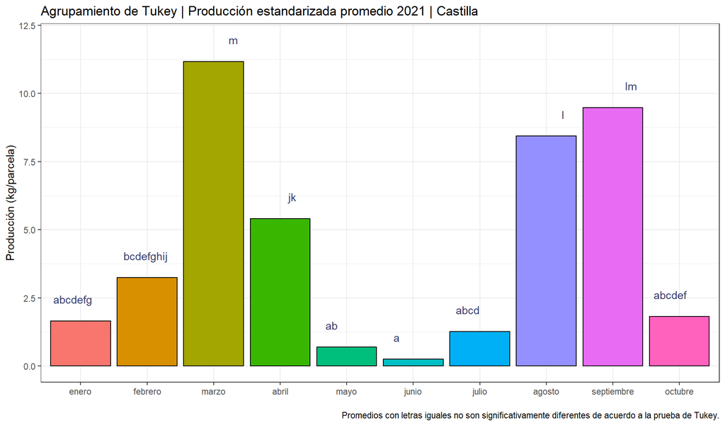

A continuación se muestra la producción estandarizada promedio de cada mes para el genotipo San Antonio; donde se destacaron nuevamente los picos mas altos de producción correspondientes a los meses septiembre con 4.921 kg, marzo con 5.590 kg y finalmente agosto con 5.622 kg.

| Genotipo_estandarizado | Month | emmean | SE | .group |
| --- | --- | --- | --- | --- |
| San Antonio Estandarizada | junio | 0.7886905 | 0.4936973 | abc |
| San Antonio Estandarizada | mayo | 0.7992063 | 0.4654623 | abc |
| San Antonio Estandarizada | octubre | 1.0042659 | 0.4936973 | abc |
| San Antonio Estandarizada | abril | 1.4254850 | 0.4654623 | abcde |
| San Antonio Estandarizada | julio | 1.5189594 | 0.4654623 | abcde |
| San Antonio Estandarizada | enero | 3.1056878 | 0.5700725 | bcdefghij |
| San Antonio Estandarizada | febrero | 3.8938776 | 0.5277846 | defghijk |
| San Antonio Estandarizada | septiembre | 4.9214286 | 0.4654623 | ijk |
| San Antonio Estandarizada | marzo | 5.5897707 | 0.4654623 | jk |
| San Antonio Estandarizada | agosto | 5.6224868 | 0.4654623 | jk |

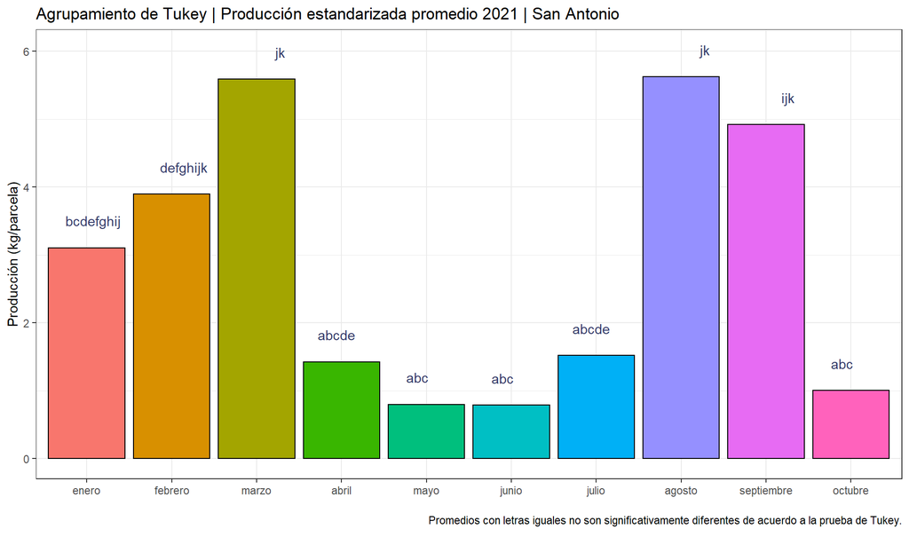

Finalmente a continuación se muestra la producción promedio del genotipo Brazos para cada mes; donde se evidenció 1 solo pico de producción correspondiente al mes de mayo; este pico de producción fue estadisticamente igual a los meses de febrero, abril, enero, septiembre, agosto y junio.

| Genotipo_estandarizado | Month | emmean | SE | .group |
| --- | --- | --- | --- | --- |
| Brazos Estandarizada | octubre | 2.200000 | 0.4936973 | abcdefgh |
| Brazos Estandarizada | marzo | 2.633333 | 0.4654623 | abcdefghi |
| Brazos Estandarizada | julio | 3.200000 | 0.4654623 | cdefghij |
| Brazos Estandarizada | febrero | 3.400000 | 0.5277846 | cdefghijk |
| Brazos Estandarizada | abril | 3.800000 | 0.4654623 | efghijk |
| Brazos Estandarizada | enero | 4.183333 | 0.5700725 | efghijk |
| Brazos Estandarizada | septiembre | 4.188889 | 0.4654623 | fghijk |
| Brazos Estandarizada | agosto | 4.377778 | 0.4654623 | ghijk |
| Brazos Estandarizada | junio | 4.787500 | 0.4936973 | hijk |
| Brazos Estandarizada | mayo | 5.922222 | 0.4654623 | k |

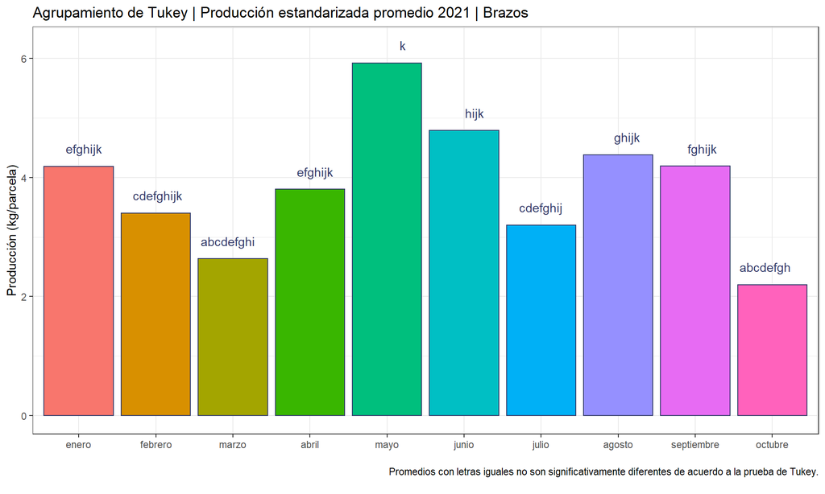

# Analisis de datos de temperatura

Debido a que se contó con estaciones climaticas dentro de los macrotuneles, a continuación se mostrará el comportamiento de la variable temperatura para el año 202 y 2021.

La siguiente figura muestra la variación de la temperatura agrupada en temperatura ambiental, temperatura máxima y temperatura mínima. Es importante mencionar que en los meses de noviembre y diciembre no hubo profesional técnico encargado del cultivo, y por esta razon no se cuenta con datos de temperatura para dichos meses.

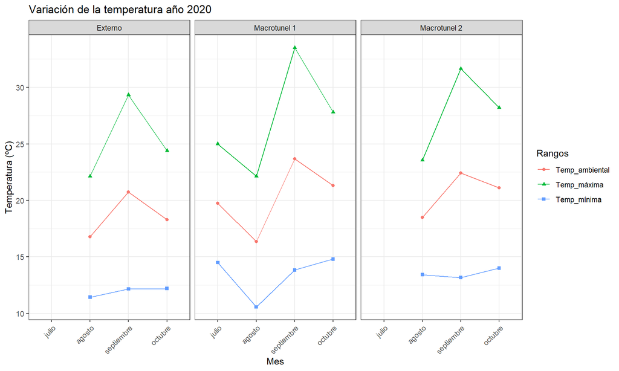

La siguiente figura muestra la variacion de la temperatura para el año 2021; en la cual se puede destacar la función de los macrotuneles para la conservación de la temperatura mínima. Observando detenidamente la grafica, se puede concluir que la temperatura mínima del macrotunel 1 y 2 fue un poco mayor a la temperatura mínima del exterior.

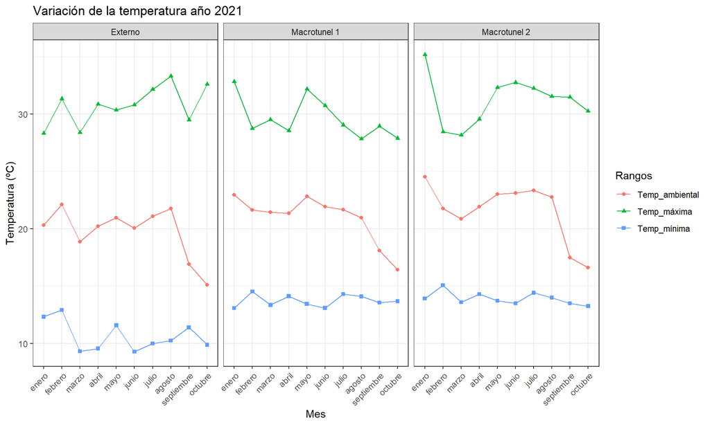

Como se afirmó previamente, en la siguiente grafica se puede apreciar de una mejor forma la variación de la temperatura en función de los macrotuneles; en donde la temperatura mínima promedio del macrotunel 1 y 2 fue 13.73ºC y 13.93ºC respectivamente, mientras que la del externo fue de 10.65ºC. De esta manera se estaría afirmando que los macrotuneles si funcionan para conservar la temperatura.

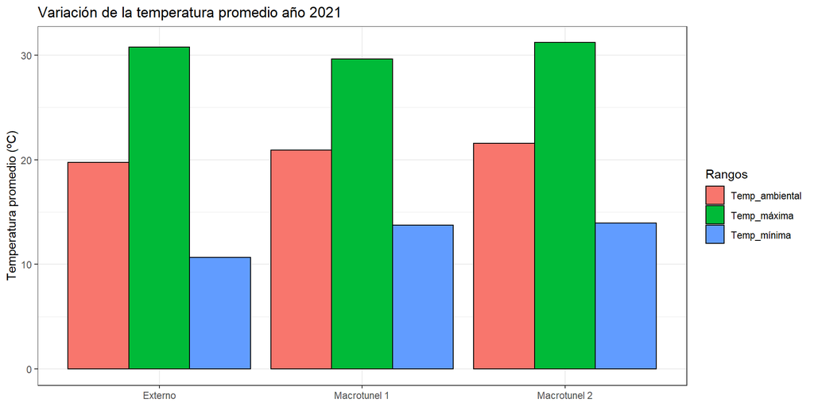

# Producción acumulada estandarizada

A continuación se muestran las graficas de producción estandarizada acumulada de cada mes para cada tipo de material evaluado con la variable temperatura con el objetivo de correlacionar algún tipo de efecto en la producción.

# Castilla sin espinas

El material Castilla no muestra ninguna relación con la variable clima

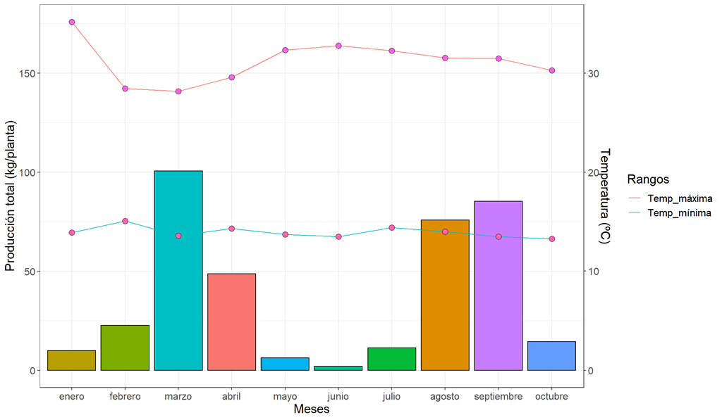

# Brazos

El material Brazos no muestra ninguna relación con la variable clima

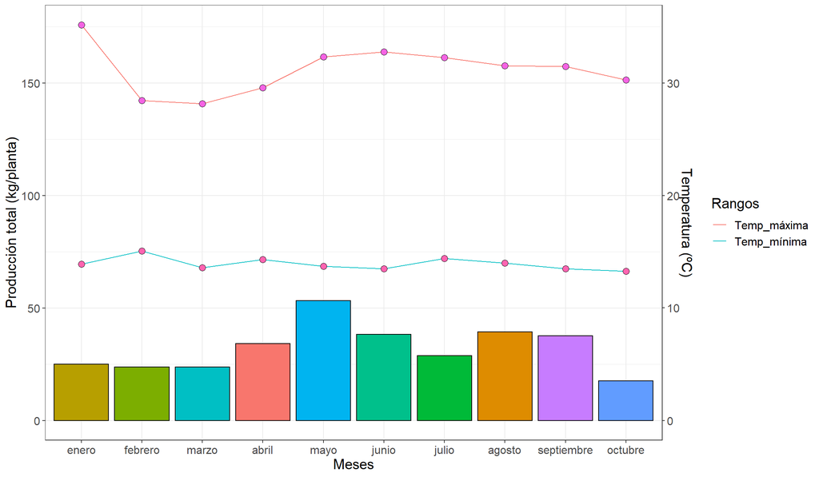

# San Antonio

El material San Antonio no muestra ninguna relación con la variable clima

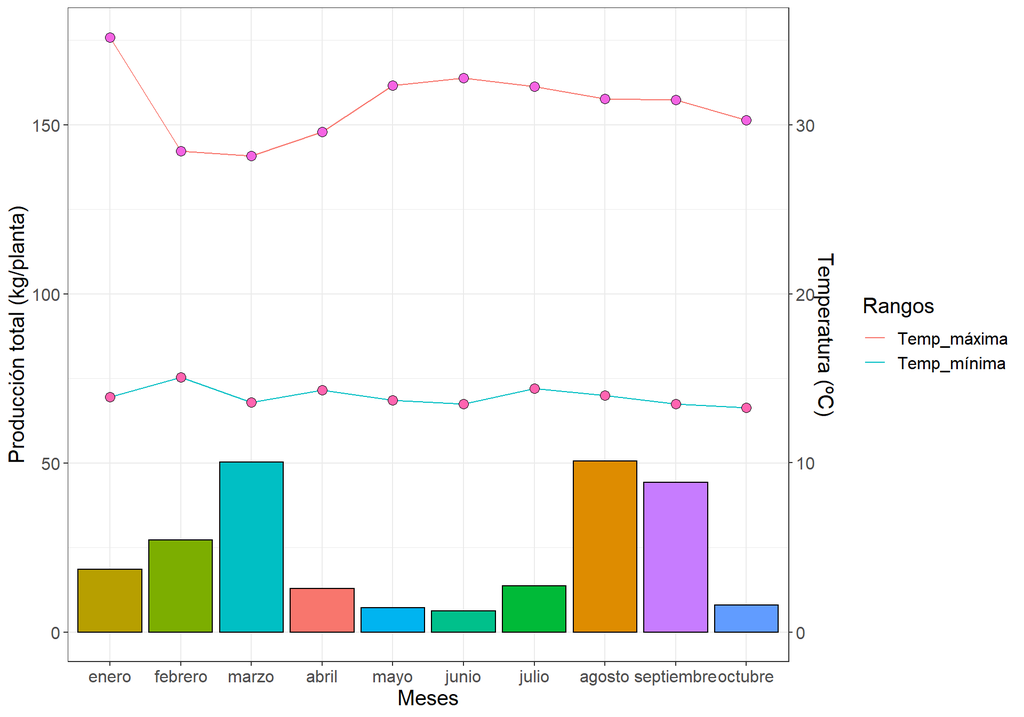

# Estimación de la variable rendimiento

A continuación se muestran las respuestas para la variable rendimiento estimado para los materiales evaluados. Esta estimación se calculo mediante la producción acumulada estandarizada multiplicada por la cantidad de plantas disponibles en un área de 1 hectárea.

# Castilla sin espinas Rendimiento T/ha sin clima

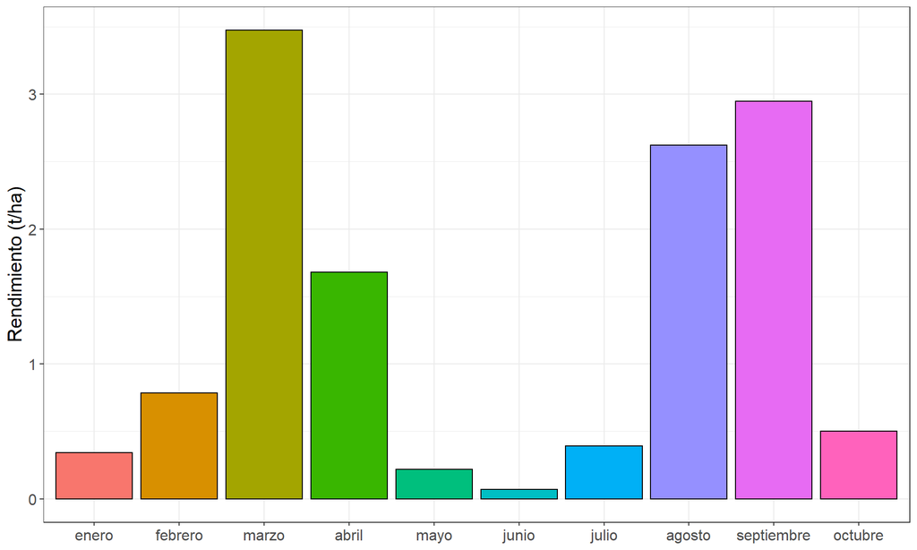